# Workshop I

Louis-Alassane Cassaignard-Viaud

February 15, 2023

# Workshops Structure

- SurveyCTO
- Quarto/Advanced R
- **Workshop I: Intro and common survey language**
- Workshop II: Monitoring and quality checks - Thursday 16/02
- Workshop III: Data Cleaning - Tuesday 21/02
- Workshop IV: Output and analyses - Thursday 23/02
- Workshop V: Basics of Quarto - Tuesday 28/02
- Workshop VI: Visualisations - Thursday 02/03
- Workshop VII: Useful Packages to know - Tuesday 07/03
- Workshop VIII: Additional Features - Thursday 09/03

# The Process

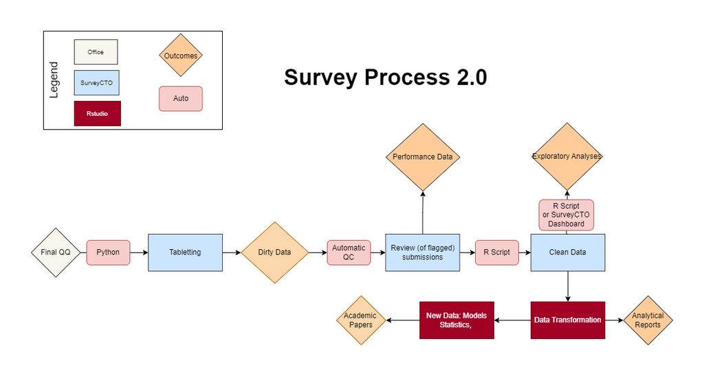

# Before the field

- Update enumerator’s list
- Translate QQ to our common language
- Tabletting
- Workshop

That’s it

## Deal with enumerators

- Theory
- Practice

**int** - YYMMXX

> Year they were recruited , Month they were recruited, Unique Number (01,02,03,04), should be in order they join
1. Create/Update Enumerator’s List (don’t forget projects )
2. Update Admin list (for contracts)
3. Generate QR codes
4. Give their ID/QR codes to enumerators

During/After the field:

- Update list with blacklisted people (add B to their ID’s)
1. Create a “fake enumerators” list
2. For the sake of Workshop fill the list as if people joined on different months/year
3. Update the “Admin” list
4. Generate QR codes (tip: use an extension)

## Create a Survey

- Theory
- Practice

Use a common language

Commonalities:

1. Questionnaires/IDs
2. Question Types
3. Recurrent Variables
4. Recurrent Values
- Translate “NDI_Modified” using our new language

## Final Request

Please take the time to go through the surveyCTO documentation related to your part of the survey process ! We need to make sure that we don’t miss out on useful features!

**->** Link is on github

[figure not shown]

Survey Process 2.0